# Data Preprocessing and Visualization

# Install dan Import Package

```r
install.packages("dplyr")
install.packages("ggplot2")
install.packages("validate")
install.packages("GGally")
install.packages("tidyr")
install.packages("Hmisc")
```

```r
library(dplyr)
library(ggplot2)
library(validate)
library("GGally")
library(tidyr)
library(Hmisc)
```

# Import Data

Data yang digunakan adalah data bawaan yang tersedia dari package ggplot2 yaitu `msleep`, yaitu waktu tidur beberapa hewan mamalia

```r
data(msleep)

data <- msleep

head(data)
```

| name | genus | vore | order | conservation | sleep_total | sleep_rem | sleep_cycle | awake | brainwt | bodywt |
| --- | --- | --- | --- | --- | --- | --- | --- | --- | --- | --- |
| Cheetah | Acinonyx | carni | Carnivora | lc | 12.1 | NA | NA | 11.9 | NA | 50.000 |
| Owl monkey | Aotus | omni | Primates | NA | 17.0 | 1.8 | NA | 7.0 | 0.016 | 0.480 |
| Mountain beaver | Aplodontia | herbi | Rodentia | nt | 14.4 | 2.4 | NA | 9.6 | NA | 1.350 |
| Greater short-tailed shrew | Blarina | omni | Soricomorpha | lc | 14.9 | 2.3 | 0.133 | 9.1 | 0.000 | 0.019 |
| Cow | Bos | herbi | Artiodactyla | domesticated | 4.0 | 0.7 | 0.667 | 20.0 | 0.423 | 600.000 |
| Three-toed sloth | Bradypus | herbi | Pilosa | NA | 14.4 | 2.2 | 0.767 | 9.6 | NA | 3.850 |

```r
?msleep
```

# Explore Data

## Melihat Sekilas

Melihat banyaknya baris dan kolom dari data

```r
dim(data)
```

```
## [1] 83 11
```

```r
nrow(data)
```

```
## [1] 83
```

```r
ncol(data)
```

```
## [1] 11
```

Bisa juga menggunakan `glimpse` untuk cek dimensi data sekaligus melihat tipe dari setip variabel

```r
glimpse(data)
```

```
## Rows: 83
## Columns: 11
## $ name         <chr> "Cheetah", "Owl monkey", "Mountain beaver", "Greater shor…
## $ genus        <chr> "Acinonyx", "Aotus", "Aplodontia", "Blarina", "Bos", "Bra…
## $ vore         <chr> "carni", "omni", "herbi", "omni", "herbi", "herbi", "carn…
## $ order        <chr> "Carnivora", "Primates", "Rodentia", "Soricomorpha", "Art…
## $ conservation <chr> "lc", NA, "nt", "lc", "domesticated", NA, "vu", NA, "dome…
## $ sleep_total  <dbl> 12.1, 17.0, 14.4, 14.9, 4.0, 14.4, 8.7, 7.0, 10.1, 3.0, 5…
## $ sleep_rem    <dbl> NA, 1.8, 2.4, 2.3, 0.7, 2.2, 1.4, NA, 2.9, NA, 0.6, 0.8, …
## $ sleep_cycle  <dbl> NA, NA, NA, 0.1333333, 0.6666667, 0.7666667, 0.3833333, N…
## $ awake        <dbl> 11.9, 7.0, 9.6, 9.1, 20.0, 9.6, 15.3, 17.0, 13.9, 21.0, 1…
## $ brainwt      <dbl> NA, 0.01550, NA, 0.00029, 0.42300, NA, NA, NA, 0.07000, 0…
## $ bodywt       <dbl> 50.000, 0.480, 1.350, 0.019, 600.000, 3.850, 20.490, 0.04…
```

Untuk mengambil nama kolom

```r
colnames(data)
```

```
##  [1] "name"         "genus"        "vore"         "order"        "conservation"
##  [6] "sleep_total"  "sleep_rem"    "sleep_cycle"  "awake"        "brainwt"
## [11] "bodywt"
```

Melihat nilai unik dari suatu variabel

```r
unique(data$order)
```

```
##  [1] "Carnivora"       "Primates"        "Rodentia"        "Soricomorpha"
##  [5] "Artiodactyla"    "Pilosa"          "Cingulata"       "Hyracoidea"
##  [9] "Didelphimorphia" "Proboscidea"     "Chiroptera"      "Perissodactyla"
## [13] "Erinaceomorpha"  "Cetacea"         "Lagomorpha"      "Diprotodontia"
## [17] "Monotremata"     "Afrosoricida"    "Scandentia"
```

Melihat jumlah data untuk setiap kategori pada variabel kategorik

```r
table(data$order)
```

```
##
##    Afrosoricida    Artiodactyla       Carnivora         Cetacea      Chiroptera
##               1               6              12               3               2
##       Cingulata Didelphimorphia   Diprotodontia  Erinaceomorpha      Hyracoidea
##               2               2               2               2               3
##      Lagomorpha     Monotremata  Perissodactyla          Pilosa        Primates
##               1               1               3               1              12
##     Proboscidea        Rodentia      Scandentia    Soricomorpha
##               2              22               1               5
```

Melihat statistik dari variabel

```r
print(paste("Rata-rata: ", mean(data$awake, na.rm = TRUE)))
```

```
## [1] "Rata-rata:  13.5674698795181"
```

```r
print(paste("Median:", median(data$awake, na.rm=TRUE)))
```

```
## [1] "Median: 13.9"
```

```r
print(paste("Min:", min(data$awake, na.rm=TRUE)))
```

```
## [1] "Min: 4.1"
```

```r
print(paste("Max:", max(data$awake, na.rm=TRUE)))
```

```
## [1] "Max: 22.1"
```

```r
print(paste("Standar Deviasi:", sd(data$awake, na.rm=TRUE)))
```

```
## [1] "Standar Deviasi: 4.4520852454348"
```

```r
print(paste("Varians:", var(data$awake, na.rm=TRUE)))
```

```
## [1] "Varians: 19.8210630326183"
```

```r
print("Quantile")
```

```
## [1] "Quantile"
```

```r
quantile(data$awake, probs = c(0.25, 0.50, 0.80), na.rm = TRUE)
```

```
##   25%   50%   80%
## 10.25 13.90 17.76
```

Melihat summary dari data

```r
summary(data)
```

```
##      name              genus               vore              order
##  Length:83          Length:83          Length:83          Length:83
##  Class :character   Class :character   Class :character   Class :character
##  Mode  :character   Mode  :character   Mode  :character   Mode  :character
##
##
##
##
##  conservation        sleep_total      sleep_rem      sleep_cycle
##  Length:83          Min.   : 1.90   Min.   :0.100   Min.   :0.1167
##  Class :character   1st Qu.: 7.85   1st Qu.:0.900   1st Qu.:0.1833
##  Mode  :character   Median :10.10   Median :1.500   Median :0.3333
##                     Mean   :10.43   Mean   :1.875   Mean   :0.4396
##                     3rd Qu.:13.75   3rd Qu.:2.400   3rd Qu.:0.5792
##                     Max.   :19.90   Max.   :6.600   Max.   :1.5000
##                                     NA's   :22      NA's   :51
##      awake          brainwt            bodywt
##  Min.   : 4.10   Min.   :0.00014   Min.   :   0.005
##  1st Qu.:10.25   1st Qu.:0.00290   1st Qu.:   0.174
##  Median :13.90   Median :0.01240   Median :   1.670
##  Mean   :13.57   Mean   :0.28158   Mean   : 166.136
##  3rd Qu.:16.15   3rd Qu.:0.12550   3rd Qu.:  41.750
##  Max.   :22.10   Max.   :5.71200   Max.   :6654.000
##                  NA's   :27
```

## Check Missing Value

Jumlah missing value secara keseluruhan

```r
sum(is.na(data))
```

```
## [1] 136
```

```r
sum(is.na(data$conservation))
```

```
## [1] 29
```

Untuk menghitung jumlah missing value untuk setiap variabel dapat menggunakan bantuan fungsi `sapply` untuk melakukan looping setiap variabel

```r
sapply(data, FUN = function(x) sum(is.na(x)))
```

```
##         name        genus         vore        order conservation  sleep_total
##            0            0            7            0           29            0
##    sleep_rem  sleep_cycle        awake      brainwt       bodywt
##           22           51            0           27            0
```

Untuk memfilter data yang missing bisa menggunakan fungsi `which`

```r
data[which(is.na(data$conservation)),]
```

| name | genus | vore | order | conservation | sleep_total | sleep_rem | sleep_cycle | awake | brainwt | bodywt |
| --- | --- | --- | --- | --- | --- | --- | --- | --- | --- | --- |
| Owl monkey | Aotus | omni | Primates | NA | 17.0 | 1.8 | NA | 7.0 | 0.016 | 0.480 |
| Three-toed sloth | Bradypus | herbi | Pilosa | NA | 14.4 | 2.2 | 0.767 | 9.6 | NA | 3.850 |
| Vesper mouse | Calomys | NA | Rodentia | NA | 7.0 | NA | NA | 17.0 | NA | 0.045 |
| African giant pouched rat | Cricetomys | omni | Rodentia | NA | 8.3 | 2.0 | NA | 15.7 | 0.007 | 1.000 |
| Western american chipmunk | Eutamias | herbi | Rodentia | NA | 14.9 | NA | NA | 9.1 | NA | 0.071 |
| Galago | Galago | omni | Primates | NA | 9.8 | 1.1 | 0.550 | 14.2 | 0.005 | 0.200 |
| Human | Homo | omni | Primates | NA | 8.0 | 1.9 | 1.500 | 16.0 | 1.320 | 62.000 |
| Macaque | Macaca | omni | Primates | NA | 10.1 | 1.2 | 0.750 | 13.9 | 0.179 | 6.800 |
| Vole | Microtus | herbi | Rodentia | NA | 12.8 | NA | NA | 11.2 | NA | 0.035 |
| Little brown bat | Myotis | insecti | Chiroptera | NA | 19.9 | 2.0 | 0.200 | 4.1 | 0.000 | 0.010 |
| Slow loris | Nyctibeus | carni | Primates | NA | 11.0 | NA | NA | 13.0 | 0.013 | 1.400 |
| Chimpanzee | Pan | omni | Primates | NA | 9.7 | 1.4 | 1.417 | 14.3 | 0.440 | 52.200 |
| Baboon | Papio | omni | Primates | NA | 9.4 | 1.0 | 0.667 | 14.6 | 0.180 | 25.235 |
| Deer mouse | Peromyscus | NA | Rodentia | NA | 11.5 | NA | NA | 12.5 | NA | 0.021 |
| Phalanger | Phalanger | NA | Diprotodontia | NA | 13.7 | 1.8 | NA | 10.3 | 0.011 | 1.620 |
| Potoroo | Potorous | herbi | Diprotodontia | NA | 11.1 | 1.5 | NA | 12.9 | NA | 1.100 |
| African striped mouse | Rhabdomys | omni | Rodentia | NA | 8.7 | NA | NA | 15.3 | NA | 0.044 |
| Squirrel monkey | Saimiri | omni | Primates | NA | 9.6 | 1.4 | NA | 14.4 | 0.020 | 0.743 |
| Cotton rat | Sigmodon | herbi | Rodentia | NA | 11.3 | 1.1 | 0.150 | 12.7 | 0.001 | 0.148 |
| Mole rat | Spalax | NA | Rodentia | NA | 10.6 | 2.4 | NA | 13.4 | 0.003 | 0.122 |
| Musk shrew | Suncus | NA | Soricomorpha | NA | 12.8 | 2.0 | 0.183 | 11.2 | 0.000 | 0.048 |
| Short-nosed echidna | Tachyglossus | insecti | Monotremata | NA | 8.6 | NA | NA | 15.4 | 0.025 | 4.500 |
| Eastern american chipmunk | Tamias | herbi | Rodentia | NA | 15.8 | NA | NA | 8.2 | NA | 0.112 |
| Tenrec | Tenrec | omni | Afrosoricida | NA | 15.6 | 2.3 | NA | 8.4 | 0.003 | 0.900 |
| Tree shrew | Tupaia | omni | Scandentia | NA | 8.9 | 2.6 | 0.233 | 15.1 | 0.002 | 0.104 |
| Bottle-nosed dolphin | Tursiops | carni | Cetacea | NA | 5.2 | NA | NA | 18.8 | NA | 173.330 |
| Genet | Genetta | carni | Carnivora | NA | 6.3 | 1.3 | NA | 17.7 | 0.018 | 2.000 |
| Arctic fox | Vulpes | carni | Carnivora | NA | 12.5 | NA | NA | 11.5 | 0.044 | 3.380 |
| Red fox | Vulpes | carni | Carnivora | NA | 9.8 | 2.4 | 0.350 | 14.2 | 0.050 | 4.230 |

## Dplyr

Untuk mempermudah explore data digunakan library `dplyr`. Di dplyr terdapat operator pipes `%>%`. Operator pipes akan mengambil output dari operan sebelah kiri dan menggunakannya menjadi argumen pertama pada fungsi yang ada di operan sebelah kanan.

```r
select(data, name, conservation)
```

| name | conservation |
| --- | --- |
| Cheetah | lc |
| Owl monkey | NA |
| Mountain beaver | nt |
| Greater short-tailed shrew | lc |
| Cow | domesticated |
| Three-toed sloth | NA |
| Northern fur seal | vu |
| Vesper mouse | NA |
| Dog | domesticated |
| Roe deer | lc |
| Goat | lc |
| Guinea pig | domesticated |
| Grivet | lc |
| Chinchilla | domesticated |
| Star-nosed mole | lc |
| African giant pouched rat | NA |
| Lesser short-tailed shrew | lc |
| Long-nosed armadillo | lc |
| Tree hyrax | lc |
| North American Opossum | lc |
| Asian elephant | en |
| Big brown bat | lc |
| Horse | domesticated |
| Donkey | domesticated |
| European hedgehog | lc |
| Patas monkey | lc |
| Western american chipmunk | NA |
| Domestic cat | domesticated |
| Galago | NA |
| Giraffe | cd |

[output cut: 53 more lines]

```r
data %>% select(name, conservation)
```

| name | conservation |
| --- | --- |
| Cheetah | lc |
| Owl monkey | NA |
| Mountain beaver | nt |
| Greater short-tailed shrew | lc |
| Cow | domesticated |
| Three-toed sloth | NA |
| Northern fur seal | vu |
| Vesper mouse | NA |
| Dog | domesticated |
| Roe deer | lc |
| Goat | lc |
| Guinea pig | domesticated |
| Grivet | lc |
| Chinchilla | domesticated |
| Star-nosed mole | lc |
| African giant pouched rat | NA |
| Lesser short-tailed shrew | lc |
| Long-nosed armadillo | lc |
| Tree hyrax | lc |
| North American Opossum | lc |
| Asian elephant | en |
| Big brown bat | lc |
| Horse | domesticated |
| Donkey | domesticated |
| European hedgehog | lc |
| Patas monkey | lc |
| Western american chipmunk | NA |
| Domestic cat | domesticated |
| Galago | NA |
| Giraffe | cd |

[output cut: 53 more lines]

Dua perintah diatas menghasilkan output yang sama. Namun perintah kedua lebih mudah dibaca daripada perintah pertama

### Select data

Fungsi `select()` dari dplyr dapat digunakan untuk memilih kolom yang diinginkan

```r
data %>% select(name, sleep_total)
```

| name | sleep_total |
| --- | --- |
| Cheetah | 12.1 |
| Owl monkey | 17.0 |
| Mountain beaver | 14.4 |
| Greater short-tailed shrew | 14.9 |
| Cow | 4.0 |
| Three-toed sloth | 14.4 |
| Northern fur seal | 8.7 |
| Vesper mouse | 7.0 |
| Dog | 10.1 |
| Roe deer | 3.0 |
| Goat | 5.3 |
| Guinea pig | 9.4 |
| Grivet | 10.0 |
| Chinchilla | 12.5 |
| Star-nosed mole | 10.3 |
| African giant pouched rat | 8.3 |
| Lesser short-tailed shrew | 9.1 |
| Long-nosed armadillo | 17.4 |
| Tree hyrax | 5.3 |
| North American Opossum | 18.0 |
| Asian elephant | 3.9 |
| Big brown bat | 19.7 |
| Horse | 2.9 |
| Donkey | 3.1 |
| European hedgehog | 10.1 |
| Patas monkey | 10.9 |
| Western american chipmunk | 14.9 |
| Domestic cat | 12.5 |
| Galago | 9.8 |
| Giraffe | 1.9 |

[output cut: 53 more lines]

Dapat menggunakan `-` untuk mengecualikan kolom tertentu

```r
data %>% select(-name, -genus)
```

| vore | order | conservation | sleep_total | sleep_rem | sleep_cycle | awake | brainwt | bodywt |
| --- | --- | --- | --- | --- | --- | --- | --- | --- |
| carni | Carnivora | lc | 12.1 | NA | NA | 11.90 | NA | 50.000 |
| omni | Primates | NA | 17.0 | 1.8 | NA | 7.00 | 0.016 | 0.480 |
| herbi | Rodentia | nt | 14.4 | 2.4 | NA | 9.60 | NA | 1.350 |
| omni | Soricomorpha | lc | 14.9 | 2.3 | 0.133 | 9.10 | 0.000 | 0.019 |
| herbi | Artiodactyla | domesticated | 4.0 | 0.7 | 0.667 | 20.00 | 0.423 | 600.000 |
| herbi | Pilosa | NA | 14.4 | 2.2 | 0.767 | 9.60 | NA | 3.850 |
| carni | Carnivora | vu | 8.7 | 1.4 | 0.383 | 15.30 | NA | 20.490 |
| NA | Rodentia | NA | 7.0 | NA | NA | 17.00 | NA | 0.045 |
| carni | Carnivora | domesticated | 10.1 | 2.9 | 0.333 | 13.90 | 0.070 | 14.000 |
| herbi | Artiodactyla | lc | 3.0 | NA | NA | 21.00 | 0.098 | 14.800 |
| herbi | Artiodactyla | lc | 5.3 | 0.6 | NA | 18.70 | 0.115 | 33.500 |
| herbi | Rodentia | domesticated | 9.4 | 0.8 | 0.217 | 14.60 | 0.005 | 0.728 |
| omni | Primates | lc | 10.0 | 0.7 | NA | 14.00 | NA | 4.750 |
| herbi | Rodentia | domesticated | 12.5 | 1.5 | 0.117 | 11.50 | 0.006 | 0.420 |
| omni | Soricomorpha | lc | 10.3 | 2.2 | NA | 13.70 | 0.001 | 0.060 |
| omni | Rodentia | NA | 8.3 | 2.0 | NA | 15.70 | 0.007 | 1.000 |
| omni | Soricomorpha | lc | 9.1 | 1.4 | 0.150 | 14.90 | 0.000 | 0.005 |
| carni | Cingulata | lc | 17.4 | 3.1 | 0.383 | 6.60 | 0.011 | 3.500 |
| herbi | Hyracoidea | lc | 5.3 | 0.5 | NA | 18.70 | 0.012 | 2.950 |
| omni | Didelphimorphia | lc | 18.0 | 4.9 | 0.333 | 6.00 | 0.006 | 1.700 |
| herbi | Proboscidea | en | 3.9 | NA | NA | 20.10 | 4.603 | 2547.000 |
| insecti | Chiroptera | lc | 19.7 | 3.9 | 0.117 | 4.30 | 0.000 | 0.023 |
| herbi | Perissodactyla | domesticated | 2.9 | 0.6 | 1.000 | 21.10 | 0.655 | 521.000 |
| herbi | Perissodactyla | domesticated | 3.1 | 0.4 | NA | 20.90 | 0.419 | 187.000 |
| omni | Erinaceomorpha | lc | 10.1 | 3.5 | 0.283 | 13.90 | 0.004 | 0.770 |
| omni | Primates | lc | 10.9 | 1.1 | NA | 13.10 | 0.115 | 10.000 |
| herbi | Rodentia | NA | 14.9 | NA | NA | 9.10 | NA | 0.071 |
| carni | Carnivora | domesticated | 12.5 | 3.2 | 0.417 | 11.50 | 0.026 | 3.300 |
| omni | Primates | NA | 9.8 | 1.1 | 0.550 | 14.20 | 0.005 | 0.200 |
| herbi | Artiodactyla | cd | 1.9 | 0.4 | NA | 22.10 | NA | 899.995 |

[output cut: 53 more lines]

Bisa mengambil kolom yang berawal kata tertentu menggunakan fungsi `starts_with`

```r
data %>% select(
  name,
  starts_with("sleep")
)
```

| name | sleep_total | sleep_rem | sleep_cycle |
| --- | --- | --- | --- |
| Cheetah | 12.1 | NA | NA |
| Owl monkey | 17.0 | 1.8 | NA |
| Mountain beaver | 14.4 | 2.4 | NA |
| Greater short-tailed shrew | 14.9 | 2.3 | 0.133 |
| Cow | 4.0 | 0.7 | 0.667 |
| Three-toed sloth | 14.4 | 2.2 | 0.767 |
| Northern fur seal | 8.7 | 1.4 | 0.383 |
| Vesper mouse | 7.0 | NA | NA |
| Dog | 10.1 | 2.9 | 0.333 |
| Roe deer | 3.0 | NA | NA |
| Goat | 5.3 | 0.6 | NA |
| Guinea pig | 9.4 | 0.8 | 0.217 |
| Grivet | 10.0 | 0.7 | NA |
| Chinchilla | 12.5 | 1.5 | 0.117 |
| Star-nosed mole | 10.3 | 2.2 | NA |
| African giant pouched rat | 8.3 | 2.0 | NA |
| Lesser short-tailed shrew | 9.1 | 1.4 | 0.150 |
| Long-nosed armadillo | 17.4 | 3.1 | 0.383 |
| Tree hyrax | 5.3 | 0.5 | NA |
| North American Opossum | 18.0 | 4.9 | 0.333 |
| Asian elephant | 3.9 | NA | NA |
| Big brown bat | 19.7 | 3.9 | 0.117 |
| Horse | 2.9 | 0.6 | 1.000 |
| Donkey | 3.1 | 0.4 | NA |
| European hedgehog | 10.1 | 3.5 | 0.283 |
| Patas monkey | 10.9 | 1.1 | NA |
| Western american chipmunk | 14.9 | NA | NA |
| Domestic cat | 12.5 | 3.2 | 0.417 |
| Galago | 9.8 | 1.1 | 0.550 |
| Giraffe | 1.9 | 0.4 | NA |

[output cut: 53 more lines]

Selain `starts_with` bisa juga menggunakan `ends_with` atau `contains`

### Arrange Data

`arrange()` dapat digunakan untuk mengurutkan data. Secara default akan diurutkan dari yang terkecil ke yang terbesar

```r
data %>% arrange(sleep_total)
```

| name | genus | vore | order | conservation | sleep_total | sleep_rem | sleep_cycle | awake | brainwt | bodywt |
| --- | --- | --- | --- | --- | --- | --- | --- | --- | --- | --- |
| Giraffe | Giraffa | herbi | Artiodactyla | cd | 1.9 | 0.4 | NA | 22.10 | NA | 899.995 |
| Pilot whale | Globicephalus | carni | Cetacea | cd | 2.7 | 0.1 | NA | 21.35 | NA | 800.000 |
| Horse | Equus | herbi | Perissodactyla | domesticated | 2.9 | 0.6 | 1.000 | 21.10 | 0.655 | 521.000 |
| Roe deer | Capreolus | herbi | Artiodactyla | lc | 3.0 | NA | NA | 21.00 | 0.098 | 14.800 |
| Donkey | Equus | herbi | Perissodactyla | domesticated | 3.1 | 0.4 | NA | 20.90 | 0.419 | 187.000 |
| African elephant | Loxodonta | herbi | Proboscidea | vu | 3.3 | NA | NA | 20.70 | 5.712 | 6654.000 |
| Caspian seal | Phoca | carni | Carnivora | vu | 3.5 | 0.4 | NA | 20.50 | NA | 86.000 |
| Sheep | Ovis | herbi | Artiodactyla | domesticated | 3.8 | 0.6 | NA | 20.20 | 0.175 | 55.500 |
| Asian elephant | Elephas | herbi | Proboscidea | en | 3.9 | NA | NA | 20.10 | 4.603 | 2547.000 |
| Cow | Bos | herbi | Artiodactyla | domesticated | 4.0 | 0.7 | 0.667 | 20.00 | 0.423 | 600.000 |
| Brazilian tapir | Tapirus | herbi | Perissodactyla | vu | 4.4 | 1.0 | 0.900 | 19.60 | 0.169 | 207.501 |
| Bottle-nosed dolphin | Tursiops | carni | Cetacea | NA | 5.2 | NA | NA | 18.80 | NA | 173.330 |
| Goat | Capri | herbi | Artiodactyla | lc | 5.3 | 0.6 | NA | 18.70 | 0.115 | 33.500 |
| Tree hyrax | Dendrohyrax | herbi | Hyracoidea | lc | 5.3 | 0.5 | NA | 18.70 | 0.012 | 2.950 |
| Rock hyrax | Procavia | NA | Hyracoidea | lc | 5.4 | 0.5 | NA | 18.60 | 0.021 | 3.600 |
| Common porpoise | Phocoena | carni | Cetacea | vu | 5.6 | NA | NA | 18.45 | NA | 53.180 |
| Gray seal | Haliochoerus | carni | Carnivora | lc | 6.2 | 1.5 | NA | 17.80 | 0.325 | 85.000 |
| Gray hyrax | Heterohyrax | herbi | Hyracoidea | lc | 6.3 | 0.6 | NA | 17.70 | 0.012 | 2.625 |
| Genet | Genetta | carni | Carnivora | NA | 6.3 | 1.3 | NA | 17.70 | 0.018 | 2.000 |
| Vesper mouse | Calomys | NA | Rodentia | NA | 7.0 | NA | NA | 17.00 | NA | 0.045 |
| Degu | Octodon | herbi | Rodentia | lc | 7.7 | 0.9 | NA | 16.30 | NA | 0.210 |
| Human | Homo | omni | Primates | NA | 8.0 | 1.9 | 1.500 | 16.00 | 1.320 | 62.000 |
| African giant pouched rat | Cricetomys | omni | Rodentia | NA | 8.3 | 2.0 | NA | 15.70 | 0.007 | 1.000 |
| Rabbit | Oryctolagus | herbi | Lagomorpha | domesticated | 8.4 | 0.9 | 0.417 | 15.60 | 0.012 | 2.500 |
| Eastern american mole | Scalopus | insecti | Soricomorpha | lc | 8.4 | 2.1 | 0.167 | 15.60 | 0.001 | 0.075 |
| Short-nosed echidna | Tachyglossus | insecti | Monotremata | NA | 8.6 | NA | NA | 15.40 | 0.025 | 4.500 |
| Northern fur seal | Callorhinus | carni | Carnivora | vu | 8.7 | 1.4 | 0.383 | 15.30 | NA | 20.490 |
| African striped mouse | Rhabdomys | omni | Rodentia | NA | 8.7 | NA | NA | 15.30 | NA | 0.044 |
| Tree shrew | Tupaia | omni | Scandentia | NA | 8.9 | 2.6 | 0.233 | 15.10 | 0.002 | 0.104 |
| Lesser short-tailed shrew | Cryptotis | omni | Soricomorpha | lc | 9.1 | 1.4 | 0.150 | 14.90 | 0.000 | 0.005 |

[output cut: 53 more lines]

Untuk mengurutkan secara descending dapat menggunakan fungsi `desc`

```r
data %>% arrange(vore, desc(sleep_total))
```

| name | genus | vore | order | conservation | sleep_total | sleep_rem | sleep_cycle | awake | brainwt | bodywt |
| --- | --- | --- | --- | --- | --- | --- | --- | --- | --- | --- |
| Thick-tailed opposum | Lutreolina | carni | Didelphimorphia | lc | 19.4 | 6.6 | NA | 4.60 | NA | 0.370 |
| Long-nosed armadillo | Dasypus | carni | Cingulata | lc | 17.4 | 3.1 | 0.383 | 6.60 | 0.011 | 3.500 |
| Tiger | Panthera | carni | Carnivora | en | 15.8 | NA | NA | 8.20 | NA | 162.564 |
| Northern grasshopper mouse | Onychomys | carni | Rodentia | lc | 14.5 | NA | NA | 9.50 | NA | 0.028 |
| Lion | Panthera | carni | Carnivora | vu | 13.5 | NA | NA | 10.50 | NA | 161.499 |
| Domestic cat | Felis | carni | Carnivora | domesticated | 12.5 | 3.2 | 0.417 | 11.50 | 0.026 | 3.300 |
| Arctic fox | Vulpes | carni | Carnivora | NA | 12.5 | NA | NA | 11.50 | 0.044 | 3.380 |
| Cheetah | Acinonyx | carni | Carnivora | lc | 12.1 | NA | NA | 11.90 | NA | 50.000 |
| Slow loris | Nyctibeus | carni | Primates | NA | 11.0 | NA | NA | 13.00 | 0.013 | 1.400 |
| Jaguar | Panthera | carni | Carnivora | nt | 10.4 | NA | NA | 13.60 | 0.157 | 100.000 |
| Dog | Canis | carni | Carnivora | domesticated | 10.1 | 2.9 | 0.333 | 13.90 | 0.070 | 14.000 |
| Red fox | Vulpes | carni | Carnivora | NA | 9.8 | 2.4 | 0.350 | 14.20 | 0.050 | 4.230 |
| Northern fur seal | Callorhinus | carni | Carnivora | vu | 8.7 | 1.4 | 0.383 | 15.30 | NA | 20.490 |
| Genet | Genetta | carni | Carnivora | NA | 6.3 | 1.3 | NA | 17.70 | 0.018 | 2.000 |
| Gray seal | Haliochoerus | carni | Carnivora | lc | 6.2 | 1.5 | NA | 17.80 | 0.325 | 85.000 |
| Common porpoise | Phocoena | carni | Cetacea | vu | 5.6 | NA | NA | 18.45 | NA | 53.180 |
| Bottle-nosed dolphin | Tursiops | carni | Cetacea | NA | 5.2 | NA | NA | 18.80 | NA | 173.330 |
| Caspian seal | Phoca | carni | Carnivora | vu | 3.5 | 0.4 | NA | 20.50 | NA | 86.000 |
| Pilot whale | Globicephalus | carni | Cetacea | cd | 2.7 | 0.1 | NA | 21.35 | NA | 800.000 |
| Arctic ground squirrel | Spermophilus | herbi | Rodentia | lc | 16.6 | NA | NA | 7.40 | 0.006 | 0.920 |
| Golden-mantled ground squirrel | Spermophilus | herbi | Rodentia | lc | 15.9 | 3.0 | NA | 8.10 | NA | 0.205 |
| Eastern american chipmunk | Tamias | herbi | Rodentia | NA | 15.8 | NA | NA | 8.20 | NA | 0.112 |
| Western american chipmunk | Eutamias | herbi | Rodentia | NA | 14.9 | NA | NA | 9.10 | NA | 0.071 |
| Round-tailed muskrat | Neofiber | herbi | Rodentia | nt | 14.6 | NA | NA | 9.40 | NA | 0.266 |
| Mountain beaver | Aplodontia | herbi | Rodentia | nt | 14.4 | 2.4 | NA | 9.60 | NA | 1.350 |
| Three-toed sloth | Bradypus | herbi | Pilosa | NA | 14.4 | 2.2 | 0.767 | 9.60 | NA | 3.850 |
| Golden hamster | Mesocricetus | herbi | Rodentia | en | 14.3 | 3.1 | 0.200 | 9.70 | 0.001 | 0.120 |
| Mongolian gerbil | Meriones | herbi | Rodentia | lc | 14.2 | 1.9 | NA | 9.80 | NA | 0.053 |
| Thirteen-lined ground squirrel | Spermophilus | herbi | Rodentia | lc | 13.8 | 3.4 | 0.217 | 10.20 | 0.004 | 0.101 |
| Laboratory rat | Rattus | herbi | Rodentia | lc | 13.0 | 2.4 | 0.183 | 11.00 | 0.002 | 0.320 |

[output cut: 53 more lines]

### Filter data

`filter()` dari dplyr mengembalikan data yang memenuhi semua kondisi yang didefinisikan

```r
data %>% filter(
  sleep_total > 8,
  vore == "carni"
)
```

| name | genus | vore | order | conservation | sleep_total | sleep_rem | sleep_cycle | awake | brainwt | bodywt |
| --- | --- | --- | --- | --- | --- | --- | --- | --- | --- | --- |
| Cheetah | Acinonyx | carni | Carnivora | lc | 12.1 | NA | NA | 11.9 | NA | 50.000 |
| Northern fur seal | Callorhinus | carni | Carnivora | vu | 8.7 | 1.4 | 0.383 | 15.3 | NA | 20.490 |
| Dog | Canis | carni | Carnivora | domesticated | 10.1 | 2.9 | 0.333 | 13.9 | 0.070 | 14.000 |
| Long-nosed armadillo | Dasypus | carni | Cingulata | lc | 17.4 | 3.1 | 0.383 | 6.6 | 0.011 | 3.500 |
| Domestic cat | Felis | carni | Carnivora | domesticated | 12.5 | 3.2 | 0.417 | 11.5 | 0.026 | 3.300 |
| Thick-tailed opposum | Lutreolina | carni | Didelphimorphia | lc | 19.4 | 6.6 | NA | 4.6 | NA | 0.370 |
| Slow loris | Nyctibeus | carni | Primates | NA | 11.0 | NA | NA | 13.0 | 0.013 | 1.400 |
| Northern grasshopper mouse | Onychomys | carni | Rodentia | lc | 14.5 | NA | NA | 9.5 | NA | 0.028 |
| Tiger | Panthera | carni | Carnivora | en | 15.8 | NA | NA | 8.2 | NA | 162.564 |
| Jaguar | Panthera | carni | Carnivora | nt | 10.4 | NA | NA | 13.6 | 0.157 | 100.000 |
| Lion | Panthera | carni | Carnivora | vu | 13.5 | NA | NA | 10.5 | NA | 161.499 |
| Arctic fox | Vulpes | carni | Carnivora | NA | 12.5 | NA | NA | 11.5 | 0.044 | 3.380 |
| Red fox | Vulpes | carni | Carnivora | NA | 9.8 | 2.4 | 0.350 | 14.2 | 0.050 | 4.230 |

Bisa menggunakan fungsi `is.na` untuk mengambil/memfilter data yang missing

```r
data %>% filter(
  sleep_total > 8,
  vore == "carni",
  is.na(data$conservation)
)
```

| name | genus | vore | order | conservation | sleep_total | sleep_rem | sleep_cycle | awake | brainwt | bodywt |
| --- | --- | --- | --- | --- | --- | --- | --- | --- | --- | --- |
| Slow loris | Nyctibeus | carni | Primates | NA | 11.0 | NA | NA | 13.0 | 0.013 | 1.40 |
| Arctic fox | Vulpes | carni | Carnivora | NA | 12.5 | NA | NA | 11.5 | 0.044 | 3.38 |
| Red fox | Vulpes | carni | Carnivora | NA | 9.8 | 2.4 | 0.35 | 14.2 | 0.050 | 4.23 |

Bisa memanggil beberapa fungsi dplyr secara bersamaan dengan menggunakan operator `%>%`

```r
(data
 %>% filter(
    vore %in% c("herbi", "carni"),
    sleep_total < 3 | sleep_total > 16
  )
 %>% select(name, vore, starts_with("sleep"))
 %>% arrange(desc(sleep_total)))
```

| name | vore | sleep_total | sleep_rem | sleep_cycle |
| --- | --- | --- | --- | --- |
| Thick-tailed opposum | carni | 19.4 | 6.6 | NA |
| Long-nosed armadillo | carni | 17.4 | 3.1 | 0.383 |
| Arctic ground squirrel | herbi | 16.6 | NA | NA |
| Horse | herbi | 2.9 | 0.6 | 1.000 |
| Pilot whale | carni | 2.7 | 0.1 | NA |
| Giraffe | herbi | 1.9 | 0.4 | NA |

### Mutate

`mutate()` dari dplyr dapat digunakan untuk membuat variabel baru

```r
(data
  %>% mutate(body_brain_wt = brainwt + bodywt)
  %>% select(name, ends_with("wt")))
```

| name | brainwt | bodywt | body_brain_wt |
| --- | --- | --- | --- |
| Cheetah | NA | 50.000 | NA |
| Owl monkey | 0.016 | 0.480 | 0.496 |
| Mountain beaver | NA | 1.350 | NA |
| Greater short-tailed shrew | 0.000 | 0.019 | 0.019 |
| Cow | 0.423 | 600.000 | 600.423 |
| Three-toed sloth | NA | 3.850 | NA |
| Northern fur seal | NA | 20.490 | NA |
| Vesper mouse | NA | 0.045 | NA |
| Dog | 0.070 | 14.000 | 14.070 |
| Roe deer | 0.098 | 14.800 | 14.898 |
| Goat | 0.115 | 33.500 | 33.615 |
| Guinea pig | 0.005 | 0.728 | 0.733 |
| Grivet | NA | 4.750 | NA |
| Chinchilla | 0.006 | 0.420 | 0.426 |
| Star-nosed mole | 0.001 | 0.060 | 0.061 |
| African giant pouched rat | 0.007 | 1.000 | 1.007 |
| Lesser short-tailed shrew | 0.000 | 0.005 | 0.005 |
| Long-nosed armadillo | 0.011 | 3.500 | 3.511 |
| Tree hyrax | 0.012 | 2.950 | 2.962 |
| North American Opossum | 0.006 | 1.700 | 1.706 |
| Asian elephant | 4.603 | 2547.000 | 2551.603 |
| Big brown bat | 0.000 | 0.023 | 0.023 |
| Horse | 0.655 | 521.000 | 521.655 |
| Donkey | 0.419 | 187.000 | 187.419 |
| European hedgehog | 0.004 | 0.770 | 0.773 |
| Patas monkey | 0.115 | 10.000 | 10.115 |
| Western american chipmunk | NA | 0.071 | NA |
| Domestic cat | 0.026 | 3.300 | 3.326 |
| Galago | 0.005 | 0.200 | 0.205 |
| Giraffe | NA | 899.995 | NA |

[output cut: 53 more lines]

Bisa dibuat lebih kompleks. Contohnya menghitung persentase, menghitung zcore atau melakukan scaling data menggunakan minmax scaler

```r
(data
  %>% mutate(
    sleep_percent = sleep_total / 24 * 100,
    awake_percent = 100 - sleep_percent,
    sleep_total_minmax = (sleep_total - min(sleep_total)) / (max(sleep_total) - min(sleep_total)),
    sleep_total_zcore = ((sleep_total - mean(sleep_total)) / sd(sleep_total))
  )
  %>% select(name, contains("percent"), contains("total"), sleep_percent)
  %>% arrange(desc(sleep_percent)))
```

| name | sleep_percent | awake_percent | sleep_total | sleep_total_minmax | sleep_total_zcore |
| --- | --- | --- | --- | --- | --- |
| Little brown bat | 82.917 | 17.083 | 19.9 | 1.000 | 2.127 |
| Big brown bat | 82.083 | 17.917 | 19.7 | 0.989 | 2.082 |
| Thick-tailed opposum | 80.833 | 19.167 | 19.4 | 0.972 | 2.015 |
| Giant armadillo | 75.417 | 24.583 | 18.1 | 0.900 | 1.723 |
| North American Opossum | 75.000 | 25.000 | 18.0 | 0.894 | 1.700 |
| Long-nosed armadillo | 72.500 | 27.500 | 17.4 | 0.861 | 1.565 |
| Owl monkey | 70.833 | 29.167 | 17.0 | 0.839 | 1.475 |
| Arctic ground squirrel | 69.167 | 30.833 | 16.6 | 0.817 | 1.386 |
| Golden-mantled ground squirrel | 66.250 | 33.750 | 15.9 | 0.778 | 1.228 |
| Tiger | 65.833 | 34.167 | 15.8 | 0.772 | 1.206 |
| Eastern american chipmunk | 65.833 | 34.167 | 15.8 | 0.772 | 1.206 |
| Tenrec | 65.000 | 35.000 | 15.6 | 0.761 | 1.161 |
| Greater short-tailed shrew | 62.083 | 37.917 | 14.9 | 0.722 | 1.004 |
| Western american chipmunk | 62.083 | 37.917 | 14.9 | 0.722 | 1.004 |
| Round-tailed muskrat | 60.833 | 39.167 | 14.6 | 0.706 | 0.936 |
| Northern grasshopper mouse | 60.417 | 39.583 | 14.5 | 0.700 | 0.914 |
| Mountain beaver | 60.000 | 40.000 | 14.4 | 0.694 | 0.891 |
| Three-toed sloth | 60.000 | 40.000 | 14.4 | 0.694 | 0.891 |
| Golden hamster | 59.583 | 40.417 | 14.3 | 0.689 | 0.869 |
| Mongolian gerbil | 59.167 | 40.833 | 14.2 | 0.683 | 0.846 |
| Thirteen-lined ground squirrel | 57.500 | 42.500 | 13.8 | 0.661 | 0.756 |
| Phalanger | 57.083 | 42.917 | 13.7 | 0.656 | 0.734 |
| Lion | 56.250 | 43.750 | 13.5 | 0.644 | 0.689 |
| Laboratory rat | 54.167 | 45.833 | 13.0 | 0.617 | 0.577 |
| Vole | 53.333 | 46.667 | 12.8 | 0.606 | 0.532 |
| Musk shrew | 53.333 | 46.667 | 12.8 | 0.606 | 0.532 |
| Chinchilla | 52.083 | 47.917 | 12.5 | 0.589 | 0.464 |
| Domestic cat | 52.083 | 47.917 | 12.5 | 0.589 | 0.464 |
| House mouse | 52.083 | 47.917 | 12.5 | 0.589 | 0.464 |
| Arctic fox | 52.083 | 47.917 | 12.5 | 0.589 | 0.464 |

[output cut: 53 more lines]

### Summary Data

`summarise` dari dplty dapat digunakan untuk melakukan aggregate data

```r
data %>% summarise(
  avg_sleep = mean(sleep_total),
  min_sleep = min(sleep_total),
  max_sleep = max(sleep_total),
  total_baris = n()
)
```

| avg_sleep | min_sleep | max_sleep | total_baris |
| --- | --- | --- | --- |
| 10.434 | 1.9 | 19.9 | 83 |

### Groupby Data

Grouping hasil aggregate berdasarkan variabel tertentu

```r
(data
  #%>% filter(!is.na(vore))
  %>% group_by(vore)
  %>% summarise(
    avg_sleep = mean(sleep_total),
    min_sleep = min(sleep_total),
    max_sleep = max(sleep_total),
    total_baris = n()
  )
 #%>% arrange(desc(avg_sleep))
)
```

| vore | avg_sleep | min_sleep | max_sleep | total_baris |
| --- | --- | --- | --- | --- |
| carni | 10.379 | 2.7 | 19.4 | 19 |
| herbi | 9.509 | 1.9 | 16.6 | 32 |
| insecti | 14.940 | 8.4 | 19.9 | 5 |
| omni | 10.925 | 8.0 | 18.0 | 20 |
| NA | 10.186 | 5.4 | 13.7 | 7 |

## Validasi

Melakukan validasi terhadap data berdasarkan rules tertentu yang didefinisikan

```r
rules <- validator(
  sleep_total + awake == 24,
  sleep_total > 4 & sleep_total < 15,
  !is.na(brainwt),
  if (vore == "omni") sleep_total >= 10
)

checked <- confront(data, rules)

summary(checked)
```

| name | items | passes | fails | nNA | error | warning | expression |
| --- | --- | --- | --- | --- | --- | --- | --- |
| V1 | 83 | 81 | 2 | 0 | FALSE | FALSE | abs(sleep_total + awake - 24) <= 1e-08 |
| V2 | 83 | 61 | 22 | 0 | FALSE | FALSE | sleep_total > 4 & sleep_total < 15 |
| V3 | 83 | 56 | 27 | 0 | FALSE | FALSE | !is.na(brainwt) |
| V4 | 83 | 71 | 10 | 2 | FALSE | FALSE | vore != “omni” \| (sleep_total - 10 >= -1e-08) |

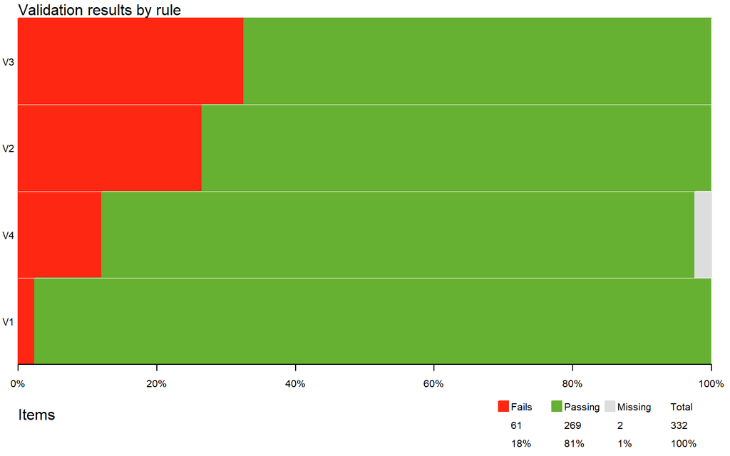

```r
plot(checked)
```

Mengambil data yang melanggar rules tertentu

```r
violating(data, checked[1]) %>%
    select(name, starts_with("sleep"), awake, brainwt, everything())
```

| name | sleep_total | sleep_rem | sleep_cycle | awake | brainwt | genus | vore | order | conservation | bodywt |
| --- | --- | --- | --- | --- | --- | --- | --- | --- | --- | --- |
| Pilot whale | 2.7 | 0.1 | NA | 21.35 | NA | Globicephalus | carni | Cetacea | cd | 800.00 |
| Common porpoise | 5.6 | NA | NA | 18.45 | NA | Phocoena | carni | Cetacea | vu | 53.18 |

Untuk lebih detail bisa cek dokumentasi lengkapnya https://data-cleaning.github.io/validate/

# Data Visualization

ggplot2 is an R package for producing statistical, or data graphics. It is the most modern of the plotting systems. The gg stands for grammar of graphics which aims to break down graphs into component chunks.

Here are some general visualizations, for more details please see this notebook https://www.kaggle.com/code/benroshan/part-4-data-visualization-with-r#Bar-Chart

## Scatter Plot

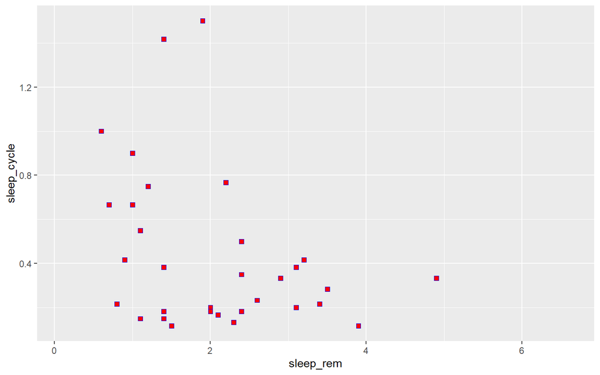

```r
(data
  %>% ggplot(aes(x=sleep_rem, y = sleep_cycle))
  + geom_point(shape = 22, color = "blue", fill = "red", size = 2)
)
```

Menambahkan garis regresi dan mewarnai titik berdasarkan variabel lain

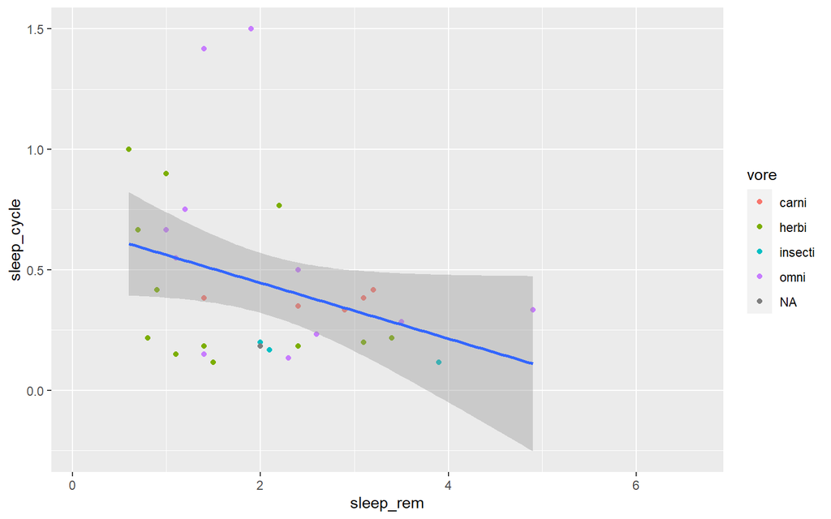

```r
(data
  %>% ggplot(aes(x=sleep_rem, y = sleep_cycle))
  + geom_point(aes(color=vore))
  + geom_smooth(method = lm)
)
```

## Barchart

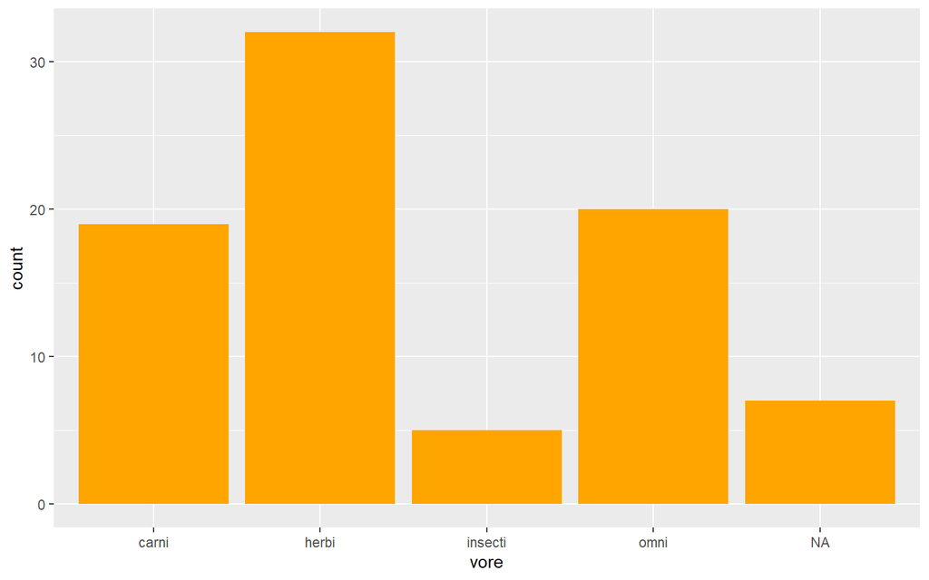

```r
(data
  %>% ggplot()
  + geom_bar(aes(x=vore), fill='orange')
)
```

Stack horizontal barchart dengan label

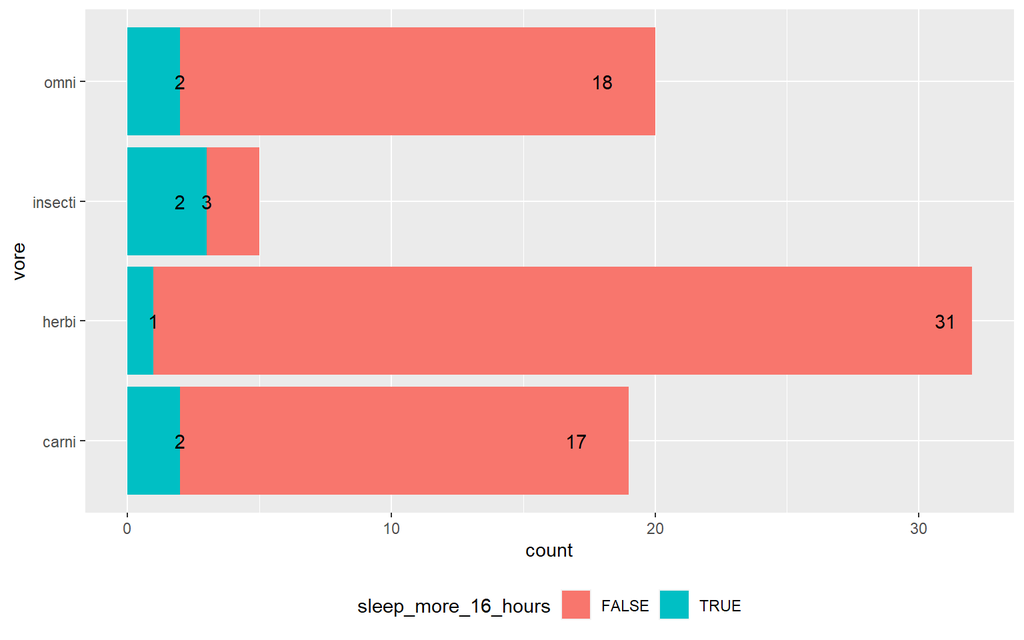

```r
(data
  %>% filter(!is.na(vore))
  %>% mutate(sleep_more_16_hours = sleep_total > 16)
  %>% ggplot(aes(x=vore, fill=sleep_more_16_hours))
  + geom_bar()
  + coord_flip()
  + theme(legend.position = "bottom")
 + geom_text(stat = "count", aes(label=stat(count)))
)
```

## Histogram

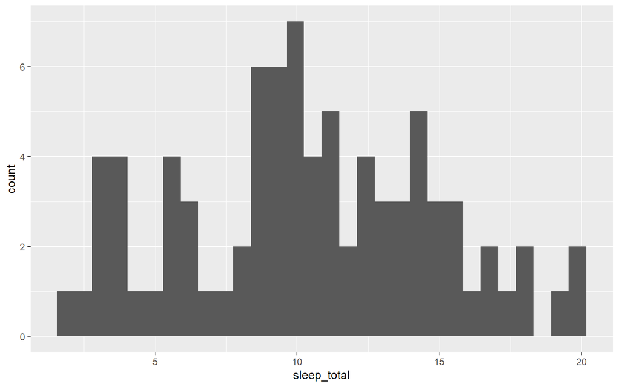

```r
data %>%
  ggplot(aes(x=sleep_total)) +
  geom_histogram()
```

Mewarnai histrogram berdasarkan kondisi tertentu

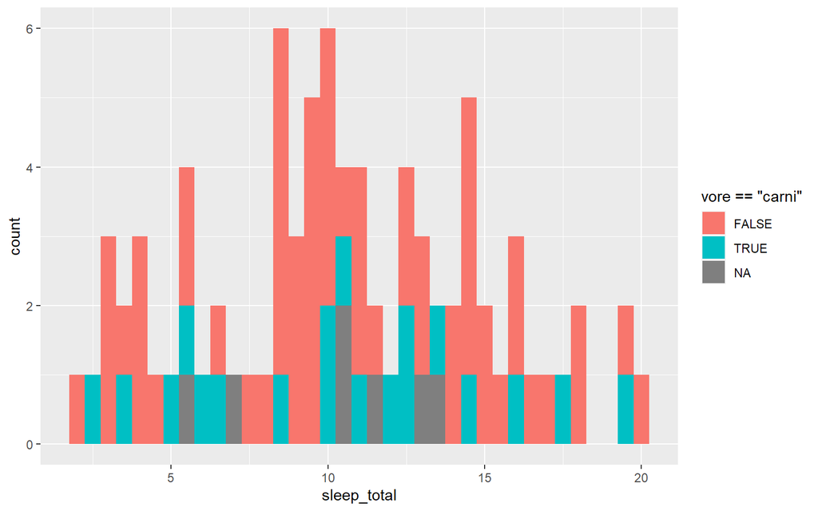

```r
data %>%
  ggplot(aes(x=sleep_total)) +
  geom_histogram(aes(fill= vore == "carni"), binwidth = 0.5)
```

## Density Plot

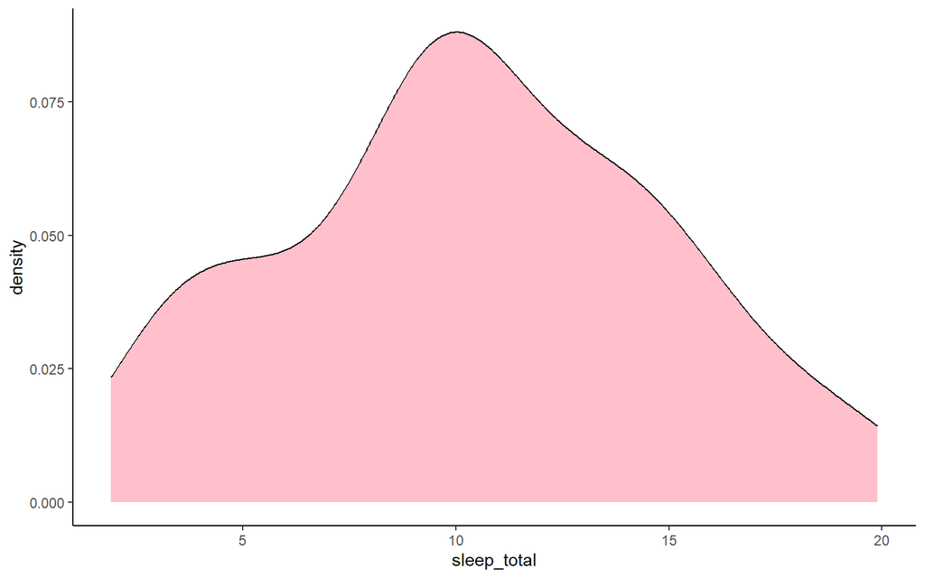

```r
data %>%
  ggplot(aes(x=sleep_total)) +
  geom_density(fill="pink") +
  theme_classic()
```

Membagi density plot berdasarkan variabel tertentu

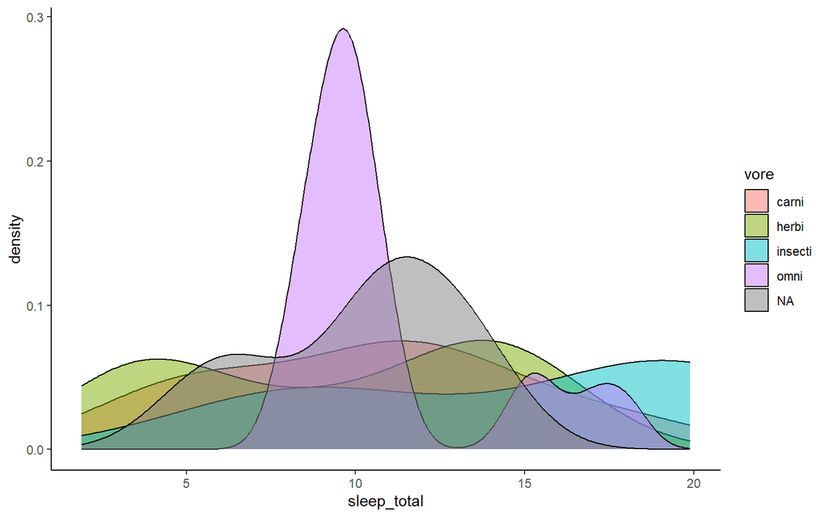

```r
data %>%
  ggplot(aes(x=sleep_total)) +
  geom_density(aes(fill=vore), alpha=0.5) +
  theme_classic()
```

## Boxplot

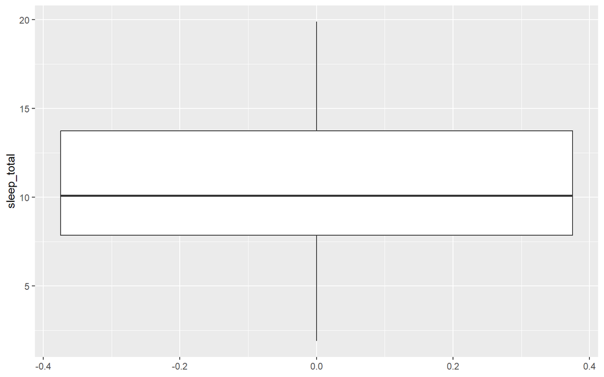

```r
data %>%
  ggplot(aes(y=sleep_total)) +
  geom_boxplot()
```

Memecah boxplot berdasarkan variabel tertentu

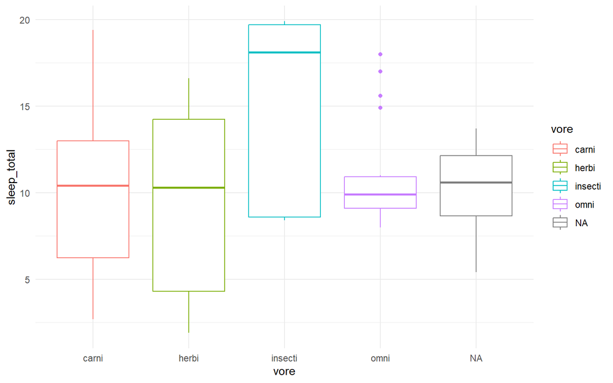

```r
data %>%
  ggplot(aes(y=sleep_total)) +
  geom_boxplot(aes(x=vore, color=vore)) +
  theme_minimal()
```

## Correlation Matrix

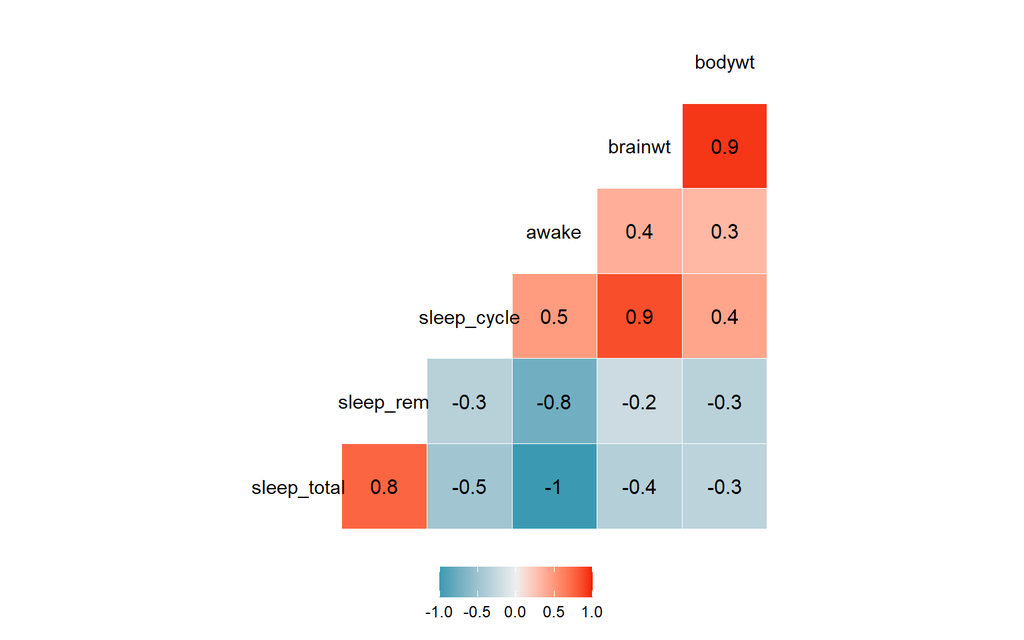

```r
ggcorr(data,  method = c("pairwise", "pearson"), label=TRUE, legend.position = "bottom")
```

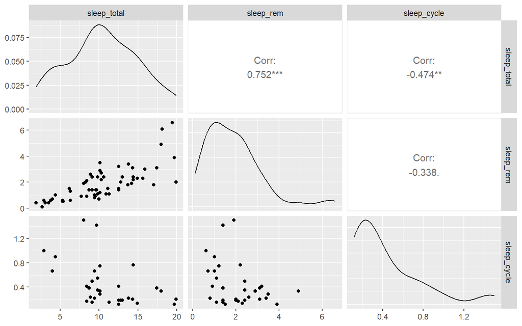

```r
data %>%
  select(contains("sleep")) %>%
  ggpairs()
```

# Handle Missing Data

## Jumlah Missing Data

Cek jumlah dan missing data. Agar kodingannya bisa dipakai berulang dibuatkan fungsi tertentu yaitu `jumlahMissing` dan `persentaseMissing`

```r
jumlahMissing <- function(df){
  sapply(df, FUN = function(x) sum(is.na(x)))
}

persentaseMissing <- function(df){
  sapply(df, FUN = function(x) sum(is.na(x)) / nrow(df) * 100 )
}
```

```r
jumlahMissing(data)
```

```
##         name        genus         vore        order conservation  sleep_total
##            0            0            7            0           29            0
##    sleep_rem  sleep_cycle        awake      brainwt       bodywt
##           22           51            0           27            0
```

```r
persentaseMissing(data)
```

```
##         name        genus         vore        order conservation  sleep_total
##     0.000000     0.000000     8.433735     0.000000    34.939759     0.000000
##    sleep_rem  sleep_cycle        awake      brainwt       bodywt
##    26.506024    61.445783     0.000000    32.530120     0.000000
```

## Menghapus Missing Data

```r
dropped_na <- drop_na(data)
jumlahMissing(dropped_na)
```

```
##         name        genus         vore        order conservation  sleep_total
##            0            0            0            0            0            0
##    sleep_rem  sleep_cycle        awake      brainwt       bodywt
##            0            0            0            0            0
```

Baris yang minimal terdapat 1 kolomnya missing value akan terhapus

```r
dropped_na
```

| name | genus | vore | order | conservation | sleep_total | sleep_rem | sleep_cycle | awake | brainwt | bodywt |
| --- | --- | --- | --- | --- | --- | --- | --- | --- | --- | --- |
| Greater short-tailed shrew | Blarina | omni | Soricomorpha | lc | 14.9 | 2.3 | 0.133 | 9.1 | 0.000 | 0.019 |
| Cow | Bos | herbi | Artiodactyla | domesticated | 4.0 | 0.7 | 0.667 | 20.0 | 0.423 | 600.000 |
| Dog | Canis | carni | Carnivora | domesticated | 10.1 | 2.9 | 0.333 | 13.9 | 0.070 | 14.000 |
| Guinea pig | Cavis | herbi | Rodentia | domesticated | 9.4 | 0.8 | 0.217 | 14.6 | 0.005 | 0.728 |
| Chinchilla | Chinchilla | herbi | Rodentia | domesticated | 12.5 | 1.5 | 0.117 | 11.5 | 0.006 | 0.420 |
| Lesser short-tailed shrew | Cryptotis | omni | Soricomorpha | lc | 9.1 | 1.4 | 0.150 | 14.9 | 0.000 | 0.005 |
| Long-nosed armadillo | Dasypus | carni | Cingulata | lc | 17.4 | 3.1 | 0.383 | 6.6 | 0.011 | 3.500 |
| North American Opossum | Didelphis | omni | Didelphimorphia | lc | 18.0 | 4.9 | 0.333 | 6.0 | 0.006 | 1.700 |
| Big brown bat | Eptesicus | insecti | Chiroptera | lc | 19.7 | 3.9 | 0.117 | 4.3 | 0.000 | 0.023 |
| Horse | Equus | herbi | Perissodactyla | domesticated | 2.9 | 0.6 | 1.000 | 21.1 | 0.655 | 521.000 |
| European hedgehog | Erinaceus | omni | Erinaceomorpha | lc | 10.1 | 3.5 | 0.283 | 13.9 | 0.004 | 0.770 |
| Domestic cat | Felis | carni | Carnivora | domesticated | 12.5 | 3.2 | 0.417 | 11.5 | 0.026 | 3.300 |
| Golden hamster | Mesocricetus | herbi | Rodentia | en | 14.3 | 3.1 | 0.200 | 9.7 | 0.001 | 0.120 |
| House mouse | Mus | herbi | Rodentia | nt | 12.5 | 1.4 | 0.183 | 11.5 | 0.000 | 0.022 |
| Rabbit | Oryctolagus | herbi | Lagomorpha | domesticated | 8.4 | 0.9 | 0.417 | 15.6 | 0.012 | 2.500 |
| Laboratory rat | Rattus | herbi | Rodentia | lc | 13.0 | 2.4 | 0.183 | 11.0 | 0.002 | 0.320 |
| Eastern american mole | Scalopus | insecti | Soricomorpha | lc | 8.4 | 2.1 | 0.167 | 15.6 | 0.001 | 0.075 |
| Thirteen-lined ground squirrel | Spermophilus | herbi | Rodentia | lc | 13.8 | 3.4 | 0.217 | 10.2 | 0.004 | 0.101 |
| Pig | Sus | omni | Artiodactyla | domesticated | 9.1 | 2.4 | 0.500 | 14.9 | 0.180 | 86.250 |
| Brazilian tapir | Tapirus | herbi | Perissodactyla | vu | 4.4 | 1.0 | 0.900 | 19.6 | 0.169 | 207.501 |

Menghapus data yang terdapat missing value pada variabel tertentu

```r
dropped_na <- drop_na(data, vore)
jumlahMissing(dropped_na)
```

```
##         name        genus         vore        order conservation  sleep_total
##            0            0            0            0           24            0
##    sleep_rem  sleep_cycle        awake      brainwt       bodywt
##           20           45            0           25            0
```

## Replace With Some Value

```r
data$sleep_rem
```

```
##  [1]  NA 1.8 2.4 2.3 0.7 2.2 1.4  NA 2.9  NA 0.6 0.8 0.7 1.5 2.2 2.0 1.4 3.1 0.5
## [20] 4.9  NA 3.9 0.6 0.4 3.5 1.1  NA 3.2 1.1 0.4 0.1 1.5 0.6 1.9 0.9  NA 6.6 1.2
## [39] 1.9 3.1  NA 1.4 2.0  NA  NA 0.9  NA 0.9 0.6 1.4  NA  NA  NA 1.0 2.7  NA  NA
## [58] 1.8 0.4  NA 1.5 6.1 0.5 2.4  NA 1.4 2.1 1.1 2.4  NA 3.4 3.0 2.0 2.4  NA  NA
## [77] 1.0 2.3 2.6  NA 1.3  NA 2.4
```

Imputasi menggunakan nilai tertentu

```r
impute(data$sleep_rem, 0)
```

```
##    1    2    3    4    5    6    7    8    9   10   11   12   13   14   15   16
## 0.0*  1.8  2.4  2.3  0.7  2.2  1.4 0.0*  2.9 0.0*  0.6  0.8  0.7  1.5  2.2  2.0
##   17   18   19   20   21   22   23   24   25   26   27   28   29   30   31   32
##  1.4  3.1  0.5  4.9 0.0*  3.9  0.6  0.4  3.5  1.1 0.0*  3.2  1.1  0.4  0.1  1.5
##   33   34   35   36   37   38   39   40   41   42   43   44   45   46   47   48
##  0.6  1.9  0.9 0.0*  6.6  1.2  1.9  3.1 0.0*  1.4  2.0 0.0* 0.0*  0.9 0.0*  0.9
##   49   50   51   52   53   54   55   56   57   58   59   60   61   62   63   64
##  0.6  1.4 0.0* 0.0* 0.0*  1.0  2.7 0.0* 0.0*  1.8  0.4 0.0*  1.5  6.1  0.5  2.4
##   65   66   67   68   69   70   71   72   73   74   75   76   77   78   79   80
## 0.0*  1.4  2.1  1.1  2.4 0.0*  3.4  3.0  2.0  2.4 0.0* 0.0*  1.0  2.3  2.6 0.0*
##   81   82   83
##  1.3 0.0*  2.4
```

Imputasi menggunakan rata-rata, median, dsb

```r
impute(data$sleep_rem, mean(data$sleep_rem, na.rm = TRUE))
```

```
##        1        2        3        4        5        6        7        8
## 1.87541*  1.80000  2.40000  2.30000  0.70000  2.20000  1.40000 1.87541*
##        9       10       11       12       13       14       15       16
##  2.90000 1.87541*  0.60000  0.80000  0.70000  1.50000  2.20000  2.00000
##       17       18       19       20       21       22       23       24
##  1.40000  3.10000  0.50000  4.90000 1.87541*  3.90000  0.60000  0.40000
##       25       26       27       28       29       30       31       32
##  3.50000  1.10000 1.87541*  3.20000  1.10000  0.40000  0.10000  1.50000
##       33       34       35       36       37       38       39       40
##  0.60000  1.90000  0.90000 1.87541*  6.60000  1.20000  1.90000  3.10000
##       41       42       43       44       45       46       47       48
## 1.87541*  1.40000  2.00000 1.87541* 1.87541*  0.90000 1.87541*  0.90000
##       49       50       51       52       53       54       55       56
##  0.60000  1.40000 1.87541* 1.87541* 1.87541*  1.00000  2.70000 1.87541*
##       57       58       59       60       61       62       63       64
## 1.87541*  1.80000  0.40000 1.87541*  1.50000  6.10000  0.50000  2.40000
##       65       66       67       68       69       70       71       72
## 1.87541*  1.40000  2.10000  1.10000  2.40000 1.87541*  3.40000  3.00000
##       73       74       75       76       77       78       79       80
##  2.00000  2.40000 1.87541* 1.87541*  1.00000  2.30000  2.60000 1.87541*
##       81       82       83
##  1.30000 1.87541*  2.40000
```

```r
impute(data$sleep_rem, median(data$sleep_rem, na.rm = TRUE))
```

```
##    1    2    3    4    5    6    7    8    9   10   11   12   13   14   15   16
## 1.5*  1.8  2.4  2.3  0.7  2.2  1.4 1.5*  2.9 1.5*  0.6  0.8  0.7  1.5  2.2  2.0
##   17   18   19   20   21   22   23   24   25   26   27   28   29   30   31   32
##  1.4  3.1  0.5  4.9 1.5*  3.9  0.6  0.4  3.5  1.1 1.5*  3.2  1.1  0.4  0.1  1.5
##   33   34   35   36   37   38   39   40   41   42   43   44   45   46   47   48
##  0.6  1.9  0.9 1.5*  6.6  1.2  1.9  3.1 1.5*  1.4  2.0 1.5* 1.5*  0.9 1.5*  0.9
##   49   50   51   52   53   54   55   56   57   58   59   60   61   62   63   64
##  0.6  1.4 1.5* 1.5* 1.5*  1.0  2.7 1.5* 1.5*  1.8  0.4 1.5*  1.5  6.1  0.5  2.4
##   65   66   67   68   69   70   71   72   73   74   75   76   77   78   79   80
## 1.5*  1.4  2.1  1.1  2.4 1.5*  3.4  3.0  2.0  2.4 1.5* 1.5*  1.0  2.3  2.6 1.5*
##   81   82   83
##  1.3 1.5*  2.4
```

Imputasi data langsung ke dataframenya

```r
data2 <- data

data2$sleep_rem <- impute(data$sleep_rem, median)

jumlahMissing(data2)
```

```
##         name        genus         vore        order conservation  sleep_total
##            0            0            7            0           29            0
##    sleep_rem  sleep_cycle        awake      brainwt       bodywt
##            0           51            0           27            0
```

# Handle Outlier

Salah satu identifikasi outlier paling cepat menggunakan boxplot

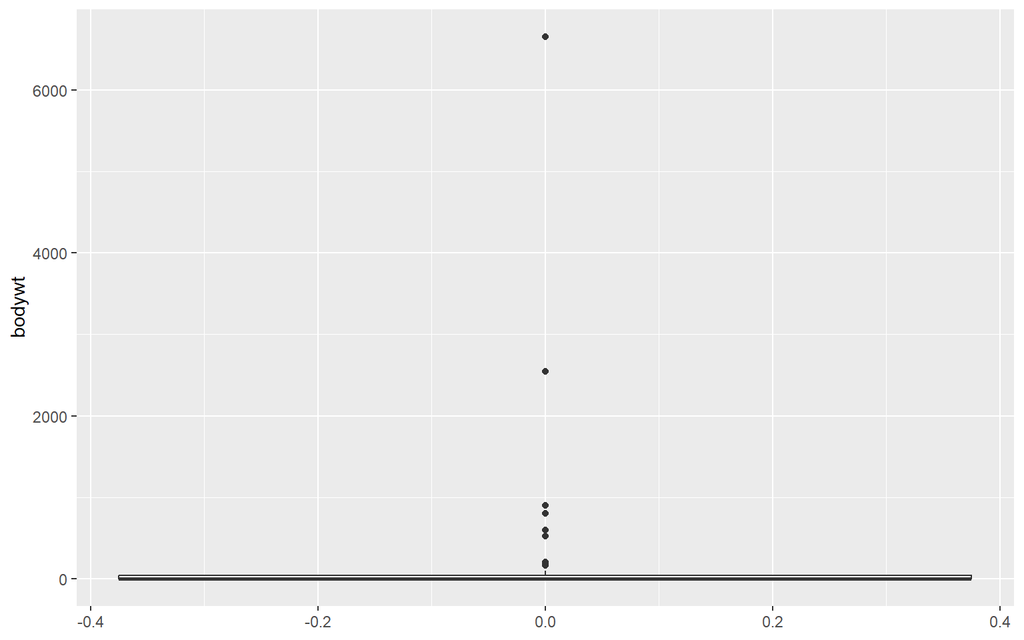

```r
data %>%
    ggplot(aes(y=bodywt)) +
    geom_boxplot()
```

## Menggunakan Z Score

Menghitung zscore, jika nilainya lebih kecil dari -3 dan lebih besar dari 3 maka termasuk outlier

```r
bodywt_data <- data %>%
  mutate(
    zcore_bodywt = (bodywt - mean(bodywt)) / sd(bodywt),
    bodywt_is_outlier = zcore_bodywt < -3 | zcore_bodywt > 3
  ) %>%
  select(name, contains("bodywt")) %>%
  arrange(desc(bodywt_is_outlier))

bodywt_data
```

| name | bodywt | zcore_bodywt | bodywt_is_outlier |
| --- | --- | --- | --- |
| Asian elephant | 2547.000 | 3.026 | TRUE |
| African elephant | 6654.000 | 8.245 | TRUE |
| Cheetah | 50.000 | -0.148 | FALSE |
| Owl monkey | 0.480 | -0.211 | FALSE |
| Mountain beaver | 1.350 | -0.209 | FALSE |
| Greater short-tailed shrew | 0.019 | -0.211 | FALSE |
| Cow | 600.000 | 0.551 | FALSE |
| Three-toed sloth | 3.850 | -0.206 | FALSE |
| Northern fur seal | 20.490 | -0.185 | FALSE |
| Vesper mouse | 0.045 | -0.211 | FALSE |
| Dog | 14.000 | -0.193 | FALSE |
| Roe deer | 14.800 | -0.192 | FALSE |
| Goat | 33.500 | -0.169 | FALSE |
| Guinea pig | 0.728 | -0.210 | FALSE |
| Grivet | 4.750 | -0.205 | FALSE |
| Chinchilla | 0.420 | -0.211 | FALSE |
| Star-nosed mole | 0.060 | -0.211 | FALSE |
| African giant pouched rat | 1.000 | -0.210 | FALSE |
| Lesser short-tailed shrew | 0.005 | -0.211 | FALSE |
| Long-nosed armadillo | 3.500 | -0.207 | FALSE |
| Tree hyrax | 2.950 | -0.207 | FALSE |
| North American Opossum | 1.700 | -0.209 | FALSE |
| Big brown bat | 0.023 | -0.211 | FALSE |
| Horse | 521.000 | 0.451 | FALSE |
| Donkey | 187.000 | 0.027 | FALSE |
| European hedgehog | 0.770 | -0.210 | FALSE |
| Patas monkey | 10.000 | -0.198 | FALSE |
| Western american chipmunk | 0.071 | -0.211 | FALSE |
| Domestic cat | 3.300 | -0.207 | FALSE |
| Galago | 0.200 | -0.211 | FALSE |

[output cut: 53 more lines]

Untuk menghapus yang outlier bisa menggunakan fungsi filter

```r
bodywt_data %>% filter(bodywt_is_outlier == FALSE)
```

| name | bodywt | zcore_bodywt | bodywt_is_outlier |
| --- | --- | --- | --- |
| Cheetah | 50.000 | -0.148 | FALSE |
| Owl monkey | 0.480 | -0.211 | FALSE |
| Mountain beaver | 1.350 | -0.209 | FALSE |
| Greater short-tailed shrew | 0.019 | -0.211 | FALSE |
| Cow | 600.000 | 0.551 | FALSE |
| Three-toed sloth | 3.850 | -0.206 | FALSE |
| Northern fur seal | 20.490 | -0.185 | FALSE |
| Vesper mouse | 0.045 | -0.211 | FALSE |
| Dog | 14.000 | -0.193 | FALSE |
| Roe deer | 14.800 | -0.192 | FALSE |
| Goat | 33.500 | -0.169 | FALSE |
| Guinea pig | 0.728 | -0.210 | FALSE |
| Grivet | 4.750 | -0.205 | FALSE |
| Chinchilla | 0.420 | -0.211 | FALSE |
| Star-nosed mole | 0.060 | -0.211 | FALSE |
| African giant pouched rat | 1.000 | -0.210 | FALSE |
| Lesser short-tailed shrew | 0.005 | -0.211 | FALSE |
| Long-nosed armadillo | 3.500 | -0.207 | FALSE |
| Tree hyrax | 2.950 | -0.207 | FALSE |
| North American Opossum | 1.700 | -0.209 | FALSE |
| Big brown bat | 0.023 | -0.211 | FALSE |
| Horse | 521.000 | 0.451 | FALSE |
| Donkey | 187.000 | 0.027 | FALSE |
| European hedgehog | 0.770 | -0.210 | FALSE |
| Patas monkey | 10.000 | -0.198 | FALSE |
| Western american chipmunk | 0.071 | -0.211 | FALSE |
| Domestic cat | 3.300 | -0.207 | FALSE |
| Galago | 0.200 | -0.211 | FALSE |
| Giraffe | 899.995 | 0.933 | FALSE |
| Pilot whale | 800.000 | 0.806 | FALSE |

[output cut: 51 more lines]

Jika ingin mereplacenya bisa menggunakan cara berikut

```r
removed_outlier <- ifelse(bodywt_data$bodywt_is_outlier, NA, bodywt_data$bodywt)
bodywt_data$bodywt <- impute(removed_outlier, mean)
bodywt_data
```

| name | bodywt | zcore_bodywt | bodywt_is_outlier |
| --- | --- | --- | --- |
| Asian elephant | 56.64589 | 3.026 | TRUE |
| African elephant | 56.64589 | 8.245 | TRUE |
| Cheetah | 50.00000 | -0.148 | FALSE |
| Owl monkey | 0.48000 | -0.211 | FALSE |
| Mountain beaver | 1.35000 | -0.209 | FALSE |
| Greater short-tailed shrew | 0.01900 | -0.211 | FALSE |
| Cow | 600.00000 | 0.551 | FALSE |
| Three-toed sloth | 3.85000 | -0.206 | FALSE |
| Northern fur seal | 20.49000 | -0.185 | FALSE |
| Vesper mouse | 0.04500 | -0.211 | FALSE |
| Dog | 14.00000 | -0.193 | FALSE |
| Roe deer | 14.80000 | -0.192 | FALSE |
| Goat | 33.50000 | -0.169 | FALSE |
| Guinea pig | 0.72800 | -0.210 | FALSE |
| Grivet | 4.75000 | -0.205 | FALSE |
| Chinchilla | 0.42000 | -0.211 | FALSE |
| Star-nosed mole | 0.06000 | -0.211 | FALSE |
| African giant pouched rat | 1.00000 | -0.210 | FALSE |
| Lesser short-tailed shrew | 0.00500 | -0.211 | FALSE |
| Long-nosed armadillo | 3.50000 | -0.207 | FALSE |
| Tree hyrax | 2.95000 | -0.207 | FALSE |
| North American Opossum | 1.70000 | -0.209 | FALSE |
| Big brown bat | 0.02300 | -0.211 | FALSE |
| Horse | 521.00000 | 0.451 | FALSE |
| Donkey | 187.00000 | 0.027 | FALSE |
| European hedgehog | 0.77000 | -0.210 | FALSE |
| Patas monkey | 10.00000 | -0.198 | FALSE |
| Western american chipmunk | 0.07100 | -0.211 | FALSE |
| Domestic cat | 3.30000 | -0.207 | FALSE |
| Galago | 0.20000 | -0.211 | FALSE |

[output cut: 53 more lines]

## Menggunakan IQR

```r
iqr <- IQR(data$bodywt, na.rm=TRUE)
q <- quantile(data$bodywt, na.rm=TRUE, c(0.25, 0.5, 0.75))

bodywt_data2 <- data %>%
  mutate(
    bodywt_is_outlier= (bodywt < (q[1] - iqr * 1.5)) | (bodywt > (q[3] + iqr * 1.5))
  ) %>%
  select(name, contains("bodywt")) %>%
  arrange(desc(bodywt_is_outlier))

bodywt_data2
```

| name | bodywt | bodywt_is_outlier |
| --- | --- | --- |
| Cow | 600.000 | TRUE |
| Asian elephant | 2547.000 | TRUE |
| Horse | 521.000 | TRUE |
| Donkey | 187.000 | TRUE |
| Giraffe | 899.995 | TRUE |
| Pilot whale | 800.000 | TRUE |
| African elephant | 6654.000 | TRUE |
| Tiger | 162.564 | TRUE |
| Lion | 161.499 | TRUE |
| Brazilian tapir | 207.501 | TRUE |
| Bottle-nosed dolphin | 173.330 | TRUE |
| Cheetah | 50.000 | FALSE |
| Owl monkey | 0.480 | FALSE |
| Mountain beaver | 1.350 | FALSE |
| Greater short-tailed shrew | 0.019 | FALSE |
| Three-toed sloth | 3.850 | FALSE |
| Northern fur seal | 20.490 | FALSE |
| Vesper mouse | 0.045 | FALSE |
| Dog | 14.000 | FALSE |
| Roe deer | 14.800 | FALSE |
| Goat | 33.500 | FALSE |
| Guinea pig | 0.728 | FALSE |
| Grivet | 4.750 | FALSE |
| Chinchilla | 0.420 | FALSE |
| Star-nosed mole | 0.060 | FALSE |
| African giant pouched rat | 1.000 | FALSE |
| Lesser short-tailed shrew | 0.005 | FALSE |
| Long-nosed armadillo | 3.500 | FALSE |
| Tree hyrax | 2.950 | FALSE |
| North American Opossum | 1.700 | FALSE |

[output cut: 53 more lines]

Cara handle sama seperti ketika menggunakan z-score. Sebagai contoh jika ingin menghapusnya

```r
bodywt_data2 %>%
  filter(bodywt_is_outlier == FALSE)
```

| name | bodywt | bodywt_is_outlier |
| --- | --- | --- |
| Cheetah | 50.000 | FALSE |
| Owl monkey | 0.480 | FALSE |
| Mountain beaver | 1.350 | FALSE |
| Greater short-tailed shrew | 0.019 | FALSE |
| Three-toed sloth | 3.850 | FALSE |
| Northern fur seal | 20.490 | FALSE |
| Vesper mouse | 0.045 | FALSE |
| Dog | 14.000 | FALSE |
| Roe deer | 14.800 | FALSE |
| Goat | 33.500 | FALSE |
| Guinea pig | 0.728 | FALSE |
| Grivet | 4.750 | FALSE |
| Chinchilla | 0.420 | FALSE |
| Star-nosed mole | 0.060 | FALSE |
| African giant pouched rat | 1.000 | FALSE |
| Lesser short-tailed shrew | 0.005 | FALSE |
| Long-nosed armadillo | 3.500 | FALSE |
| Tree hyrax | 2.950 | FALSE |
| North American Opossum | 1.700 | FALSE |
| Big brown bat | 0.023 | FALSE |
| European hedgehog | 0.770 | FALSE |
| Patas monkey | 10.000 | FALSE |
| Western american chipmunk | 0.071 | FALSE |
| Domestic cat | 3.300 | FALSE |
| Galago | 0.200 | FALSE |
| Gray seal | 85.000 | FALSE |
| Gray hyrax | 2.625 | FALSE |
| Human | 62.000 | FALSE |
| Mongoose lemur | 1.670 | FALSE |
| Thick-tailed opposum | 0.370 | FALSE |
| Macaque | 6.800 | FALSE |
| Mongolian gerbil | 0.053 | FALSE |
| Golden hamster | 0.120 | FALSE |
| Vole | 0.035 | FALSE |
| House mouse | 0.022 | FALSE |
| Little brown bat | 0.010 | FALSE |
| Round-tailed muskrat | 0.266 | FALSE |
| Slow loris | 1.400 | FALSE |
| Degu | 0.210 | FALSE |
| Northern grasshopper mouse | 0.028 | FALSE |
| Rabbit | 2.500 | FALSE |
| Sheep | 55.500 | FALSE |
| Chimpanzee | 52.200 | FALSE |
| Jaguar | 100.000 | FALSE |
| Baboon | 25.235 | FALSE |
| Desert hedgehog | 0.550 | FALSE |
| Potto | 1.100 | FALSE |
| Deer mouse | 0.021 | FALSE |
| Phalanger | 1.620 | FALSE |
| Caspian seal | 86.000 | FALSE |
| Common porpoise | 53.180 | FALSE |
| Potoroo | 1.100 | FALSE |
| Giant armadillo | 60.000 | FALSE |
| Rock hyrax | 3.600 | FALSE |
| Laboratory rat | 0.320 | FALSE |
| African striped mouse | 0.044 | FALSE |
| Squirrel monkey | 0.743 | FALSE |
| Eastern american mole | 0.075 | FALSE |
| Cotton rat | 0.148 | FALSE |
| Mole rat | 0.122 | FALSE |
| Arctic ground squirrel | 0.920 | FALSE |
| Thirteen-lined ground squirrel | 0.101 | FALSE |
| Golden-mantled ground squirrel | 0.205 | FALSE |
| Musk shrew | 0.048 | FALSE |
| Pig | 86.250 | FALSE |
| Short-nosed echidna | 4.500 | FALSE |
| Eastern american chipmunk | 0.112 | FALSE |
| Tenrec | 0.900 | FALSE |
| Tree shrew | 0.104 | FALSE |
| Genet | 2.000 | FALSE |
| Arctic fox | 3.380 | FALSE |
| Red fox | 4.230 | FALSE |